# mxnet example 3 : PapSmear 2005

The dataset is loawded from this [work](https://diagnosticpathology.biomedcentral.com/articles/10.1186/1746-1596-8-S1-S38).

The images in the dataset illustrate different status of cervix cells. The images are classed by folder for each status. Each image focus on only one cell. There is two version of each image: original image with `.BMP` extension and filtered image with `_d.bmp` extension.

first of all, I separate these two kinds of images. The first step is to apply `mxnet` only on original images. for this I moved original image from `carcinoma_in_situ/` folder to `carcinoma_in_situ_org/`, like this

```bash
# cd carcinoma_in_situ/
# mv `ls | grep '\w*.BMP'` ../carcinoma_in_situ_org/
```

In the end we have `img_data` filder which contains 7 subfolders. Each subfolder has no equal number of images. The number of images is indicated in the subfolder name.

```bash
ls img_data
## count all images
ls  img_data/* | wc -l
```

```
carcinoma_in_situ_org_150_jpeg
light_dysplastic_org_182_jpeg
moderate_dysplastic_org_146_jpeg
normal_columnar_org_98_jpeg
normal_intermediate_org_70_jpeg
normal_superficiel_org_74_jpeg
severe_dysplastic_org_197_jpeg
     930
```

## Which format we have and is there the need to change it?

We will fellow this [tutorial](https://github.com/kmezhoud/incubator-mxnet/tree/master/example/image-classification). The tutorial recommends `RecordIO`format, which concatenates multiple examples into seekable binary files for better read efficiency. The image have `.bmp` format file whish is not appropriate for this tutorial. We need to convert the to `png`or `jpeg` formats.

```r
dim(EBImage::readImage("img_data/carcinoma_in_situ_org_150/149143370-149143378-001.BMP"))
```

```
Error in EBImage::readImage("img_data/carcinoma_in_situ_org_150/149143370-149143378-001.BMP") :
  Invalid type: bmp. Currently supported formats are JPEG, PNG, and TIFF.
```

It seems that `bmp` format is not supported by `EBImage`. we try with `imager` package.

```r
dim(imager::load.image("img_data/carcinoma_in_situ_org_150/149143370-149143378-001.BMP"))
```

```
[1] 69 70  1  3
```

ok, We will use a loop to convert all images using `imager` load and save functions.

```r
require(imager)
convert_image <- function(inputFolder, outputFolder, type = '.jpeg' ){

  names_files <- list.files(inputFolder)
  nfiles <- length(list.files(inputFolder))

  for(k in 1:nfiles){
    ## get image name
    nameFile <- names_files[k]
    # load image
    tmp_img <- imager::load.image(paste0(inputFolder,nameFile, sep=""))
    # save image
    imager::save.image(im = tmp_img, file = paste0(outputFolder, tools::file_path_sans_ext(nameFile), type , sep =""),quality = 1)
  }
}
# convert_image(inputFolder = "img_data/carcinoma_in_situ_org_150/", outputFolder = "img_data/carcinoma_in_situ_org_150_jpeg/")
# convert_image("img_data/light_dysplastic_org_182/", "img_data/light_dysplastic_org_182_jpeg/")
# convert_image("img_data/moderate_dysplastic_org_146/", "img_data/moderate_dysplastic_org_146_jpeg/")
# convert_image("img_data/normal_columnar_org_98/", "img_data/normal_columnar_org_98_jpeg/")
# convert_image("img_data/normal_intermediate_org_70/", "img_data/normal_intermediate_org_70_jpeg/")
# convert_image("img_data/normal_superficiel_org_74/", "img_data/normal_superficiel_org_74_jpeg/")
# convert_image("img_data/severe_dysplastic_org_197/", "img_data/severe_dysplastic_org_197_jpeg/")
```

Now, We will use `im2rec.py` [script](https://github.com/kmezhoud/incubator-mxnet/blob/master/tools/im2rec.py) to convert our images into RecordIO format.

## convert image to RecorIO format (we will not use it)

We first prepare `mydata.lst_train.lst` and `mydata.lst_val.lst` files, which consist of the labels and image paths can be used for generating rec files. We need to create empty `mydata.lst` files before to run python script.

```r
system('python im2rec.py --list --recursive --train-ratio 0.95 mydata.lst img_data')
```

The `im2rec.py` script generates the two files and get labels for each class of cells. If we look the number of images for train and val sets

```bash
cat mydata.lst_train.lst | wc -l
cat mydata.lst_val.lst | wc -l
```

[output not shown]

```r
system('python im2rec.py --resize 480 --quality 95 --num-thread 16 mydata.lst img_data')
```

This command generates the `mydata.lst_val.rec` and `mydata.lst_train.rec` files. There are pre-setted models for `mnist`, `cifar`, and `resnet` datasets. But actually I don’t say how to use `.rec` dataset with theses models.

## Come back to our jpeg image

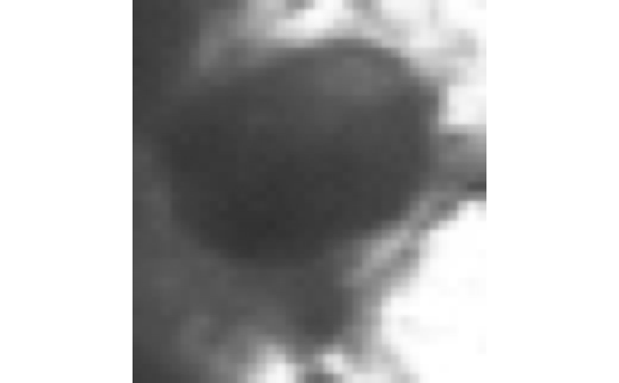

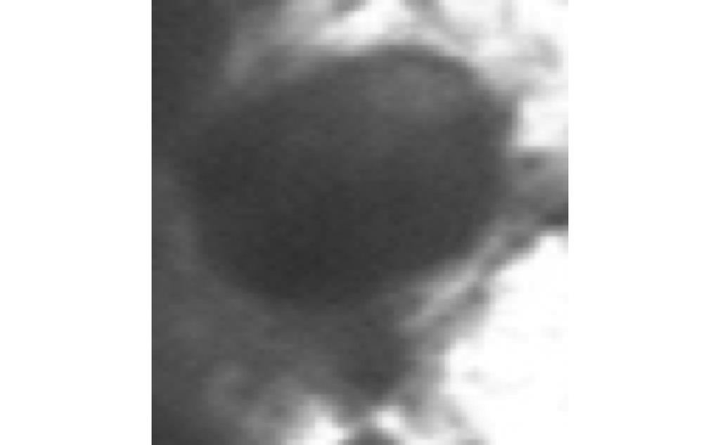

```
[[1]]
[1] 22 38

[[2]]
[1] 44 44

[[3]]
[1] 39 31

[[4]]
[1] 67 60

[[5]]
[1] 52 79

[[6]]
[1] 52 64

[[7]]
[1] 36 51

[[8]]
[1] 41 43

[[9]]
[1] 33 48

[[10]]
[1] 41 41

[[11]]
[1] 37 40
```

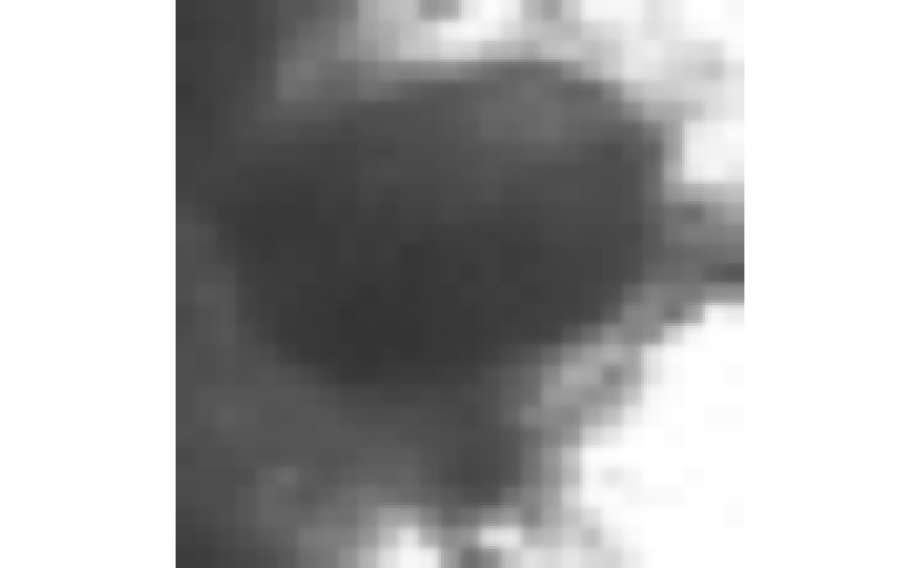

```r
## which image dimension will use. The images do not have the same dimension. We should to unify image dimension to 28x28 pixels.
## The use of bigger dimension, increase the time of the computing but not sure to have more accuracy.
get_dim_im <- function(inputFolder ){
  #inputFolder <- 'img_data/carcinoma_in_situ_org_150_jpeg/'
  names_files <- list.files(inputFolder)
  nfiles <- length(list.files(inputFolder))
  ls_dim <- list()

  for(k in 1:nfiles){
    ## get image name
    nameFile <- names_files[k]
    # load image
    tmp_img <- EBImage::readImage(paste0(inputFolder,nameFile, sep=""))

    #  Convert to grayscale
     tmp_img <- EBImage::channel(tmp_img, mode = 'gray')

    # Resize image to 28x28 pixels
    img_resized <- EBImage::resize(tmp_img, w = 28, h = 28)

    ## reduce the size of image 1/2
    ims <- EBImage::resize(tmp_img, dim(tmp_img)[1]/2)

    ls_dim[[k]] <- dim(ims)
  }
  plot(ims)
  plot(tmp_img)
  plot(img_resized)
  return(ls_dim[140:150])
}
get_dim_im("img_data/carcinoma_in_situ_org_150_jpeg/")
```

## Convert images from a folder to matrix: Each image in one row, set dimension 28x28x1.

```r
#source("../R/rbindna.R")
require(EBImage)
images2matrix <- function(inputFolder, w= 28, h = 28, class){

  names_files <- list.files(inputFolder)
  nfiles <- length(list.files(inputFolder))

  df <- data.frame(matrix(ncol = (w*h)+1, nrow = 0))
  # Set names. The first column is the labels, the other columns are the pixels.
  colnames(df) <-  c("Labels", paste("pixel", c(1:(w*h) )))

  for(k in 1:nfiles){
    ## get image name
    nameFile <- names_files[k]
    # load image
    tmp_img <- EBImage::readImage(paste0(inputFolder,nameFile, sep=""))

    ## convet to grayscale
    tmp_img <- EBImage::channel(tmp_img, mode = 'gray')

     # Resize image to 28x28 pixels
    ims <- EBImage::resize(tmp_img, w = w, h = h)
    ## reduce the size of image 1/2
    #ims <- EBImage::resize(tmp_img, dim(tmp_img)[1] * scale)

    # Get image matrix (there should be another function to do this faster and more neatly!)
    img_matrix <- ims@.Data
    #print(dim(img_matrix))

    # Coerce to a vector
    img_vector <- as.vector(img_matrix)
    #print(length(img_vector))

# > m <- matrix(1:15, nrow = 3, ncol = 5)
# > m
#      [,1] [,2] [,3] [,4] [,5]
# [1,]    1    4    7   10   13
# [2,]    2    5    8   11   14
# [3,]    3    6    9   12   15
# > t(m)
#      [,1] [,2] [,3]
# [1,]    1    2    3
# [2,]    4    5    6
# [3,]    7    8    9
# [4,]   10   11   12
# [5,]   13   14   15
# > as.vector(m)
#  [1]  1  2  3  4  5  6  7  8  9 10 11 12 13 14 15
# > as.vector(t(m))
#  [1]  1  4  7 10 13  2  5  8 11 14  3  6  9 12 15
# > matrix(as.vector(t(m)), nrow= 3, ncol = 5)
#      [,1] [,2] [,3] [,4] [,5]
# [1,]    1   10    5   14    9
# [2,]    4   13    8    3   12
# [3,]    7    2   11    6   15

    # Add label
    label <- class
    vec <- c(label, img_vector)
    # Stack in rs_df using rbind
    ## AVoid rbind, it ignore empty dataframe and colnames
    #df <- rbind(df_bkp, vec)

     df[nrow(df)+1,] <- vec

     # Print status
     print(paste(k,names_files[k],sep = " "))

  }

  rownames(df) <- NULL
  return(df)

}
class1_mat <- images2matrix("img_data/normal_intermediate_org_70_jpeg/", w=28, h=28 ,class= "ni")
```

```
[1] "1 153955676-153955721-001.jpeg"
[1] "2 153955676-153955746-001.jpeg"
[1] "3 153956279-153956296-001.jpeg"
[1] "4 153958547-153958621-001.jpeg"
[1] "5 157183332-157183388-001.jpeg"
[1] "6 157183332-157183388-002.jpeg"
[1] "7 157183412-157183656-001.jpeg"
[1] "8 157183828-157183840-001.jpeg"
[1] "9 157183828-157183877-001.jpeg"
[1] "10 157183828-157183887-001.jpeg"
[1] "11 157184013-157184023-001.jpeg"
[1] "12 157184013-157184039-001.jpeg"
[1] "13 157184067-157184080-001.jpeg"
[1] "14 157184112-157184120-001.jpeg"
[1] "15 157185575-157185586-001.jpeg"
```

[output cut: 55 more lines]

```r
class2_mat <- images2matrix("img_data/normal_columnar_org_98_jpeg/", w=28, h=28 , class= 'nc')
```

```
[1] "1 153956040-153956058-001.jpeg"
[1] "2 153956040-153956058-002.jpeg"
[1] "3 153956040-153956058-003.jpeg"
[1] "4 153956040-153956058-004.jpeg"
[1] "5 153956040-153956058-005.jpeg"
[1] "6 153956040-153956058-006.jpeg"
[1] "7 153956040-153956072-001.jpeg"
[1] "8 153956040-153956072-002.jpeg"
[1] "9 153956040-153956072-003.jpeg"
[1] "10 153956040-153956072-004.jpeg"
[1] "11 153956444-153956458-001.jpeg"
[1] "12 153956444-153956458-002.jpeg"
[1] "13 153956444-153956458-003.jpeg"
[1] "14 153956444-153956458-004.jpeg"
[1] "15 153958154-153958168-001.jpeg"
```

[output cut: 83 more lines]

```r
class3_mat <- images2matrix("img_data/normal_superficiel_org_74_jpeg/", w=28, h=28 , class= 'ns')
```

```
[1] "1 153958345-153958392-001.jpeg"
[1] "2 153960256-153960295-002.jpeg"
[1] "3 157181281-157181308-001.jpeg"
[1] "4 157181387-157181418-001.jpeg"
[1] "5 157181525-157181540-001.jpeg"
[1] "6 157181569-157181599-001.jpeg"
[1] "7 157181671-157181686-001.jpeg"
[1] "8 157181671-157181697-001.jpeg"
[1] "9 157181671-157181708-001.jpeg"
[1] "10 157183193-157183241-001.jpeg"
[1] "11 157183193-157183279-001.jpeg"
[1] "12 157183332-157183346-001.jpeg"
[1] "13 157183332-157183361-001.jpeg"
[1] "14 157183332-157183376-001.jpeg"
[1] "15 157183412-157183614-001.jpeg"
```

[output cut: 59 more lines]

```r
class4_mat <- images2matrix("img_data/light_dysplastic_org_182_jpeg/", w=28, h=28 , class= 'ld')
```

```
[1] "1 148494967-148494986-001.jpeg"
[1] "2 148495491-148495504-001.jpeg"
[1] "3 148495553-148495585-001.jpeg"
[1] "4 148495842-148495854-001.jpeg"
[1] "5 148495842-148495863-001.jpeg"
[1] "6 148495885-148495896-001.jpeg"
[1] "7 148497551-148497588-001.jpeg"
[1] "8 148497551-148497625-001.jpeg"
[1] "9 148497676-148497704-001.jpeg"
[1] "10 148497676-148497718-001.jpeg"
[1] "11 148497788-148497816-001.jpeg"
[1] "12 148497788-148497816-002.jpeg"
[1] "13 148497788-148497836-001.jpeg"
[1] "14 148497788-148497836-002.jpeg"
[1] "15 148498683-148498703-001.jpeg"
```

[output cut: 167 more lines]

```r
class5_mat <- images2matrix("img_data/moderate_dysplastic_org_146_jpeg/", w=28, h=28 , class= 'md')
```

```
[1] "1 148848523-148848538-001.jpeg"
[1] "2 148848523-148848559-001.jpeg"
[1] "3 148848523-148848559-002.jpeg"
[1] "4 148848523-148848559-003.jpeg"
[1] "5 148848523-148848559-004.jpeg"
[1] "6 149013033-149013072-001.jpeg"
[1] "7 149014631-149014646-001.jpeg"
[1] "8 149014631-149014646-002.jpeg"
[1] "9 149014631-149014646-003.jpeg"
[1] "10 149014631-149014646-004.jpeg"
[1] "11 149014631-149014654-001.jpeg"
[1] "12 149014631-149014654-002.jpeg"
[1] "13 149014631-149014654-003.jpeg"
[1] "14 149014929-149014984-001.jpeg"
[1] "15 149014929-149014994-001.jpeg"
```

[output cut: 131 more lines]

```r
class6_mat <- images2matrix("img_data/carcinoma_in_situ_org_150_jpeg/", w=28, h=28 , class= 'ci')
```

```
[1] "1 149143370-149143378-001.jpeg"
[1] "2 149143370-149143378-002.jpeg"
[1] "3 149143370-149143378-003.jpeg"
[1] "4 149143370-149143388-001.jpeg"
[1] "5 149143370-149143388-002.jpeg"
[1] "6 149143370-149143388-003.jpeg"
[1] "7 149146635-149146651-001.jpeg"
[1] "8 149146635-149146651-002.jpeg"
[1] "9 149146635-149146651-003.jpeg"
[1] "10 149146837-149146854-001.jpeg"
[1] "11 149146886-149146936-001.jpeg"
[1] "12 149146886-149146936-002.jpeg"
[1] "13 149147060-149147075-001.jpeg"
[1] "14 149147060-149147075-002.jpeg"
[1] "15 149147060-149147075-003.jpeg"
```

[output cut: 135 more lines]

```r
class7_mat <- images2matrix("img_data/severe_dysplastic_org_197_jpeg/", w=28, h=28 , class= 'sd')
```

```
[1] "1 149056321-149056343-001.jpeg"
[1] "2 149056321-149056343-002.jpeg"
[1] "3 149056321-149056343-003.jpeg"
[1] "4 149056321-149056360-001.jpeg"
[1] "5 149056321-149056360-002.jpeg"
[1] "6 149056321-149056360-003.jpeg"
[1] "7 149056410-149056423-001.jpeg"
[1] "8 149056410-149056423-002.jpeg"
[1] "9 149056410-149056423-003.jpeg"
[1] "10 149056410-149056423-004.jpeg"
[1] "11 149056410-149056444-003.jpeg"
[1] "12 149056410-149056444-004.jpeg"
[1] "13 149056410-149056444-005.jpeg"
[1] "14 149056410-149056458-001.jpeg"
[1] "15 149056410-149056458-002.jpeg"
```

[output cut: 182 more lines]

```r
list.classes <- list(class1_mat, class2_mat, class3_mat, class4_mat, class5_mat, class6_mat, class7_mat)
class1_mat[1:4, 1:4]
```

|  | Labels | pixel 1 | pixel 2 | pixel 3 |
| --- | --- | --- | --- | --- |
| 1 | ni | 0.973809523809524 | 0.599393090569561 | 0.479901960784314 |
| 2 | ni | 0.848367680405495 | 0.731969454448446 | 0.904611844737895 |
| 3 | ni | 0.747952514339069 | 0.761271175136721 | 0.807904828598106 |
| 4 | ni | 0.848334333733493 | 0.870915866346539 | 0.871800386821395 |

```r
#class2_mat[1:4, 1:4]
dim(class1_mat)
```

```
[1]  70 785
```

```r
#dim(class2_mat)
```

## Visualize image directly from row

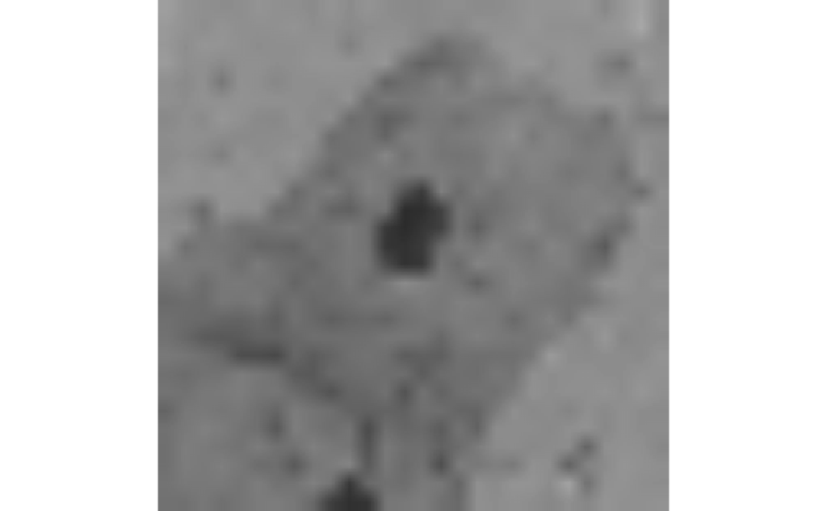

```r
## visualize image from vector
vec2img <- function(df, nrow){

 i <- EBImage::Image(as.numeric(df[nrow,]))
sqr <- sqrt(length(df[nrow,]))
dim(i) <- c(sqr,sqr, 1)
i <- EBImage::resize(i, w= 156, h= 156)

 plot(i)
}
vec2img(class1_mat[,-1], 65)
```

## Sampling Training and Testing dataset

```r
set.seed(1234)
#Train1 <-  class1_mat[sample(nrow(class1_mat),size=60,replace=FALSE),]
#Train2 <- class2_mat[sample(nrow(class2_mat), size = 130, replace = FALSE),]
## Sampling training and testing row from dataframe
sampling_train_test <- function(df, n_test= 5 ){

  test <- dplyr::sample_n(df, n_test )
  ## omit test rows from train and remove duplicates if exist
  train <-  df[-duplicated(rbind(test, df)),]

  return(list(train = train, test = test))
}
# function to merge training and testing dataset from a list of dataframes (classes)
merge_train_test <- function(list.df, n_test = 5){

  list_train_test <- lapply(list.df,sampling_train_test)

  sum_train <- data.frame()
  sum_test <- data.frame()
  for(i in 1:length(list_train_test)){

   sum_train <-rbind( sum_train, list_train_test[[i]]$train)

   sum_test <- rbind( sum_test, list_train_test[[i]]$test)

  }
  return(list(allTrain = sum_train, allTest = sum_test))

}
list_smp <- merge_train_test(list.classes, n_test= 5)
```

[output not shown]

```r
# Set up train and test arrays
train <- data.matrix(Train)
```

```
Error in is.data.frame(frame) : object 'Train' not found
```

```r
# Set up the symbolic model
#-------------------------------------------------------------------------------
require(mxnet)
data <- mx.symbol.Variable('data')
# 1st convolutional layer
conv_1 <- mx.symbol.Convolution(data = data, kernel = c(5, 5), num_filter = 20)
tanh_1 <- mx.symbol.Activation(data = conv_1, act_type = "tanh")
pool_1 <- mx.symbol.Pooling(data = tanh_1, pool_type = "max", kernel = c(2, 2), stride = c(2, 2))
# 2nd convolutional layer
conv_2 <- mx.symbol.Convolution(data = pool_1, kernel = c(5, 5), num_filter = 50)
tanh_2 <- mx.symbol.Activation(data = conv_2, act_type = "tanh")
pool_2 <- mx.symbol.Pooling(data=tanh_2, pool_type = "max", kernel = c(2, 2), stride = c(2, 2))
# 1st fully connected layer
flatten <- mx.symbol.Flatten(data = pool_2)
fc_1 <- mx.symbol.FullyConnected(data = flatten, num_hidden = 500)
tanh_3 <- mx.symbol.Activation(data = fc_1, act_type = "tanh")
# 2nd fully connected layer
fc_2 <- mx.symbol.FullyConnected(data = tanh_3, num_hidden = 40)
# Output. Softmax output since we'd like to get some probabilities.
NN_model <- mx.symbol.SoftmaxOutput(data = fc_2)
```

```r
# Pre-training set up
#-------------------------------------------------------------------------------
# Set seed for reproducibility
mx.set.seed(100)
# Device used. CPU in my case.
devices <- mx.cpu()
# Training
#-------------------------------------------------------------------------------
# Train the model
model <- mx.model.FeedForward.create(symbol = NN_model,       # The network schema
                                     X = train_array,         # Training array
                                     y = train_y,             # Labels/classes of training dataset
                                     ctx = devices,
                                     num.round = 150,
                                     array.batch.size = 20,  # The batch size used for R array training
                                     learning.rate = 0.02,
                                     momentum = 0.9,
                                     optimizer = "sgd",
                                     eval.metric = mx.metric.accuracy,
                                     #initializer=mx.init.uniform(0.05),
                                     epoch.end.callback = mx.callback.log.train.metric(100))
```

[output not shown]

```r
# Get accuracy
table(test_y, predicted_labels)
```

```
      predicted_labels
test_y 1 2 3 4 5 6 7
     1 5 0 0 0 0 0 0
     2 0 4 0 1 0 0 0
     3 0 0 5 0 0 0 0
     4 0 0 0 5 0 0 0
     5 0 0 0 0 5 0 0
     6 0 0 0 0 0 5 0
     7 0 0 0 0 0 0 5
```

```r
## get means of identical labels, located in the diagonal
sum(diag(table(test_y,predicted_labels)))/length(test_y)
```

```
[1] 0.9714286
```

## how can plot image from selected test_y Labels/classes

```r
test_y
```

```
  8  43  42  68  57  94   2  34  96  74 105  82 421 136 431
  1   1   1   1   1   2   2   2   2   2   3   3   3   3   3
```

```r
test[1:5, 1:5]
```

```
   Labels   pixel 1   pixel 2   pixel 3   pixel 4
8       1 0.5931481 0.7036114 0.6982935 0.7026261
43      1 0.6423086 0.6377714 0.6519608 0.6413866
42      1 0.6633787 0.6698980 0.6744198 0.6702614
68      1 0.6260237 0.6161531 0.5874750 0.5748833
57      1 0.2169985 0.1722289 0.2117230 0.2125759
```

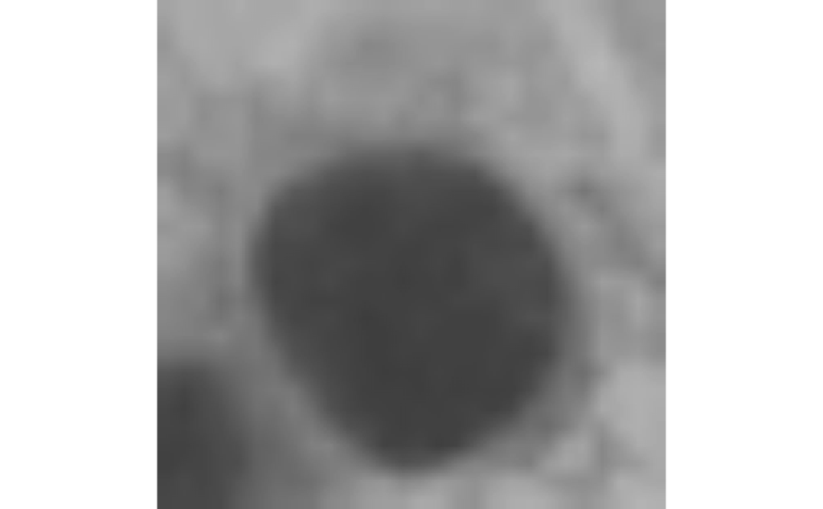

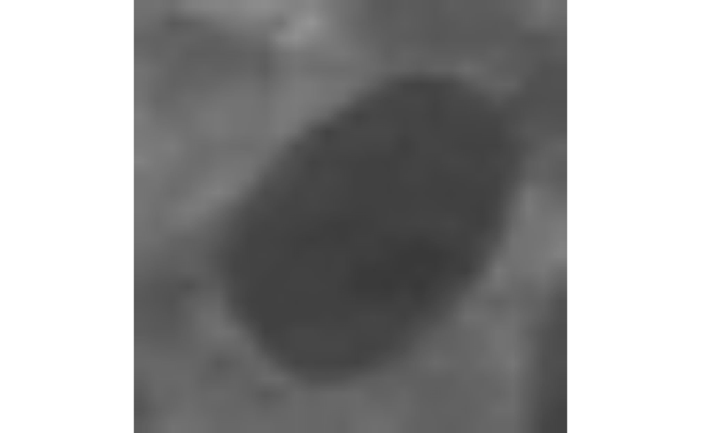

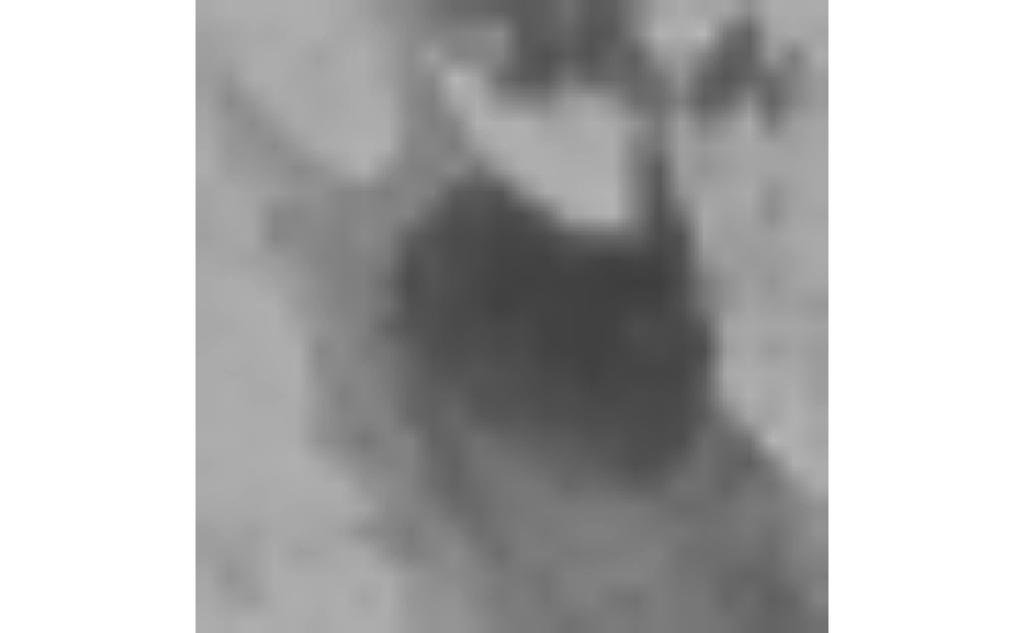

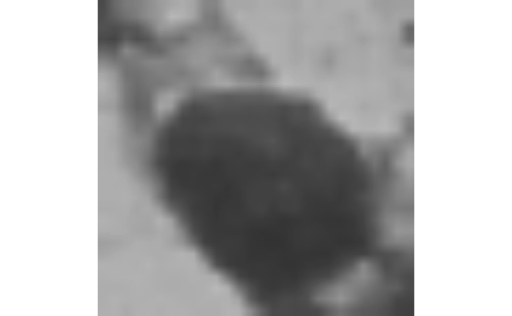

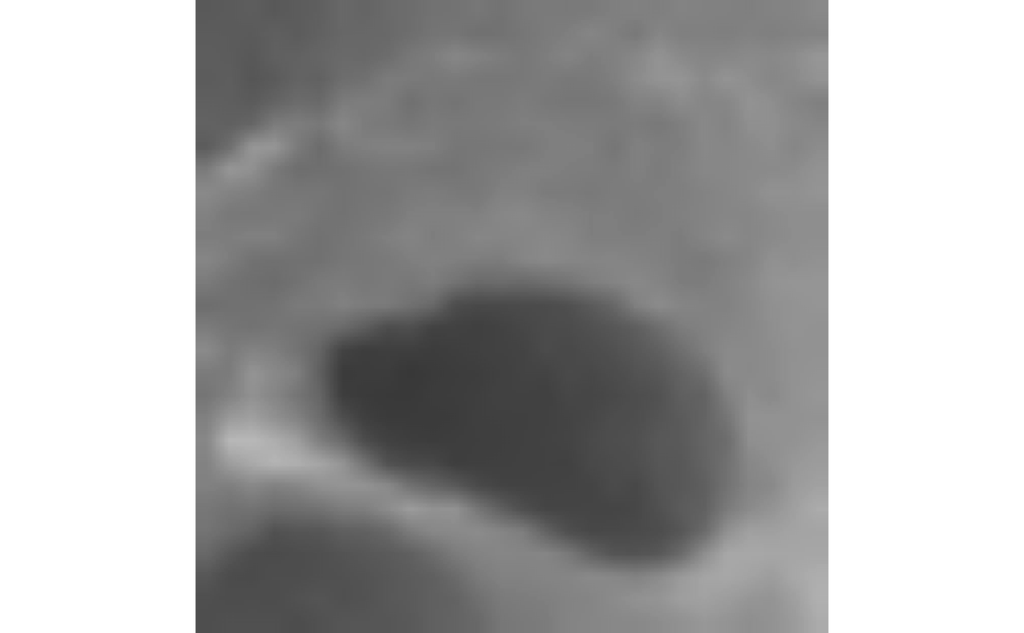

```r
## we would like to select classes 3
selected_vec <- names(test_y[test_y==7])
#class(test[selected_vec,][,-1][1:5, 1:6])
for(i in 1: length(selected_vec)){
vec2img(test[selected_vec,][,-1],i)

}
```